# Examen parcial

Simulación

Carlos Lezama [181121](https://celj.mx/)

Otoño 2021 | [ITAM](https://www.itam.mx/) | [EST 24107](https://github.com/celj/simulation-fall-2021)

Lunes, 22 de noviembre de 2021

# Problema 1

Dada una matriz $4 \times 4$ de variables aleatorias Bernoulli denotada por $\displaystyle \left[X_{ij}\right]$, sean $N(X)$ el número total de éxitos en $X$ y $D(X)$ el total de vecinos (horizontales o verticales) de dichos éxitos que difieren. Nótese que, si se escriben los elementos de $X$ en un vector $V$, existe una matriz $\displaystyle M_{24 \times 16}$ tal que $D(X)$ es la suma de valores absolutos de $MV$. El $24$ surge porque hay $24$ pares de vecinos a revisar.

Asimismo, supongamos que la distribución de $X$, $\pi(X)$, es proporcional a

$$\pi(X) \propto p^{N(X)} (1 - p)^{16 - N(X)} \exp \left( -\lambda D(X) \right).$$

Si $\lambda = 0$, las variables son independientes e idénticamente distribuidas $\text{Bernoulli}(p)$.

Hay $2^{16}$ posibles estados, uno por cada valor posible de $X$. Usaremos el método Metropolis-Hastings con los siguientes kérneles de transición:

1. Sea $q_1$ tal que cada transición es igualmente plausible con probabilidad $1/2^{16}$. Es decir, el siguiente estado candidato para $X$ es un vector de $16$ $\text{Bernoulli}(p)$ iid.
2. Sea $q_2$ tal que se elige una de las 16 entradas en $X$ con probabilidad $1/16$, y luego se determina el valor de la celda a ser $0$ o $1$ con probabilidad $0.5$ en cada caso. Entonces, a lo más puede cambiar un solo elemento de $X$ en cada transición.

Ambas $q_1$ y $q_2$ son simétricas, irreducibles y tienen diagonales positivas. Es fácil ver que la primera se mueve más rápido que la segunda.

# Problema 2

Queremos investigar el desempeño del algoritmo de Metropolis-Hastings usando una caminata aleatoria cuando la distribución objetivo es una mezcla de dos densidades normales bivariadas para $\theta = (\theta_1, \theta_2)$

$$\pi(\theta) = 0.7 \mathscr{N} (\theta \mid \mu_1,\ \Sigma_1) + 0.3 \mathscr{N} (\theta \mid \mu_2,\ \Sigma_2)$$

donde

$$\mu_1 =
\begin{pmatrix}
4 \\
5
\end{pmatrix},\
\mu_2 =
\begin{pmatrix}
0.7 \\
3.5
\end{pmatrix},\
\Sigma_1 =
\begin{pmatrix}
1 & 0.7 \\
0.7 & 1
\end{pmatrix},\
\Sigma_2 =
\begin{pmatrix}
1 & -0.7 \\
-0.7 & 1
\end{pmatrix}$$

Supongamos que no podemos muestrear $\pi$ directamente y, en su lugar, usamos Metropolis-Hastings con $\displaystyle q(y \mid x) = \mathscr{N}(y \mid x, v I_2)$ donde $v$ es un parámetro de ajuste.

# Problema 3

Sea $\displaystyle \theta = \int_0^{\pi/3} \sin(t)dt$, usaremos Monte Carlo para calcular un estimador $\hat{\theta}$.

## Monte Carlo crudo

```r
set.seed(181121)

n <- 100000
a <- 0
b <- pi / 3

sim.u     <- runif(n, a, b)
sim.sin   <- sin(sim.u)
theta.sin <- cumsum(sim.sin) / (1:n)
theta.1   <- sim.sin[which.min(abs(sim.sin - 0.5))]
sd.1      <- sd(sim.sin) / sqrt(n)
```

Nuestro estimado es: $\hat{\theta}_1 = 0.49999252$.

## Variables antitéticas

```r
sim.v     <- a + (b - sim.u)
sim.ant   <- (sin(sim.u) + sin(sim.v)) / 2
theta.ant <- cumsum(sim.ant) / (1:n)
theta.2   <- sim.ant[which.min(abs(sim.ant - 0.5))]
sd.2      <- sd(sim.ant) / sqrt(n)
```

Nuestro estimado es: $\hat{\theta}_2 = 0.5$. Asimismo, con variables antitéticas, la varianza se reduce en un $75.1521733\%$.

## Variables de control

```r
set.seed(181121)
k <- 1000

# Piloto
u <- runif(k, a, b)
x <- u
y <- cos(x)
alpha <- -lm(y ~ x)$coeff[2]

# Simulación
u <- runif(n, a, b)
x <- u
y <- cos(x)

sim.cv   <- x + alpha * (y - mean(y))
theta.cv <- cumsum(sim.cv) / (1:n)
theta.3  <- sim.cv[which.min(abs(sim.cv - 0.5))]
sd.3     <- sd(sim.cv) / sqrt(n)
```

Nuestro estimado es: $\hat{\theta}_3 = 0.50000002$. De tal forma que, con nuestra variable de control, la varianza se reduce en un $8.8113263\%$.

Gráficamente,

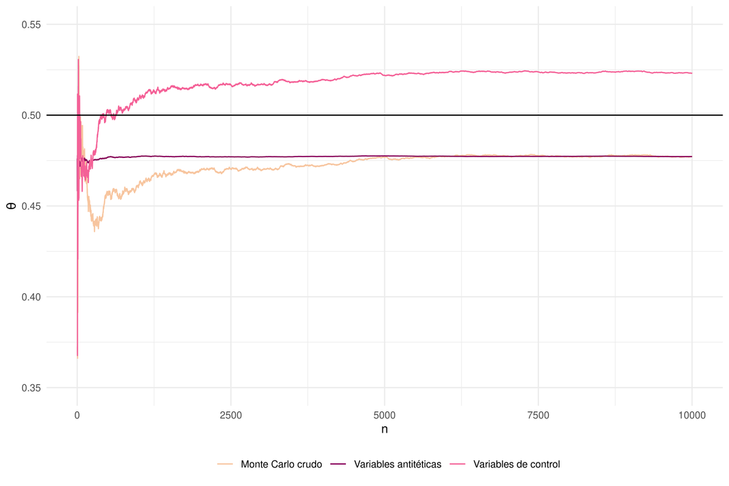

# Problema 4

Dados los siguientes números normales con $\mu = 3$ y $\sigma = 1$

```r
obs <- c(4.59, 4.153, 2.46, 2.732, 2.973)
```

la función de distribución empírica $F_n(x)$ está dada por:

$$F_5(x) =
\begin{cases}
0, & \text{si}\ \ x_{(1)} > x \\
1/5, & \text{si}\ \ x_{(1)} \leq x < x_{(2)} \\
2/5, & \text{si}\ \ x_{(2)} \leq x < x_{(3)} \\
3/5, & \text{si}\ \ x_{(3)} \leq x < x_{(4)} \\
4/5, & \text{si}\ \ x_{(4)} \leq x < x_{(5)} \\
1, & \text{si}\ \ x_{(5)} \leq x
\end{cases}$$

Asimismo,

$$\begin{align}
P(F_5(3) \leq 2/5)
&= P(F_5(3) = 0) + P(F_5(3) = 1/5) + P(F_5(3) = 2/5) \\
&= {5 \choose 0} F(3)^0 \left( 1 - F(3) \right)^{5 - 0} \\
&+ {5 \choose 1} F(3)^1 \left( 1 - F(3) \right)^{5 - 1} \\
&+ {5 \choose 2} F(3)^2 \left( 1 - F(3) \right)^{5 - 2}
\end{align}$$

donde $F(x)$ es una normal con $\mu = 3$ y $\sigma = 1$.

Así pues,

```r
mean <- 3
sd <- 1

prob <- 0

for (i in 0:2) {
  p <- choose(5, i) *
    (pnorm(3, mean, sd)) ^ (i) *
    (1 - pnorm(3, mean, sd)) ^ (5 - i)
  prob <- prob + p
}

prob
```

```
## [1] 0.5
```

De forma analítica, es fácil ver que $F(3) = \Phi(0) = 0.5$ donde $\Phi(\cdot)$ es una normal estándar. De igual modo, nótese que $F_5(x) \leq 2/5$ si y solo si $x < x_{(3)}$ donde $x_{(3)}$ es la medida de nuestra muestra. Por lo tanto, podemos concluir que $P(F_5(3) \leq 2/5) = 0.5$.